# Schmidt_Emily_TP5

## 4.5 ETS(A, A, A): Holt-Winters

This model will not be considered since the seasonality has variations that are changing proportional to the level of the time series.

## 4.6 ETS(M, M, M): Holt-Winters

```r
tourist_MMM <-  tourist |>
  model(
    `HW_MMM` = ETS(Tourists ~ error("M") + trend("M") + season("M")))

report(tourist_MMM)
```

```
## Series: Tourists
## Model: ETS(M,M,M)
##   Smoothing parameters:
##     alpha = 0.546069
##     beta  = 0.07378165
##     gamma = 0.0001000317
##
##   Initial states:
##     l[0]     b[0]     s[0]     s[-1]     s[-2]    s[-3]
##  23.3423 1.047373 1.037264 0.9611873 0.7711851 1.230363
##
##   sigma^2:  0.0039
##
##      AIC     AICc      BIC
## 418.4280 421.5315 438.4036
```

```r
fabletools::accuracy(tourist_MMM)
```

```
## # A tibble: 1 × 10
##   .model .type        ME  RMSE   MAE    MPE  MAPE  MASE RMSSE    ACF1
##   <chr>  <chr>     <dbl> <dbl> <dbl>  <dbl> <dbl> <dbl> <dbl>   <dbl>
## 1 HW_MMM Training -0.161  2.16  1.67 -0.912  4.50 0.555 0.610 -0.0491
```

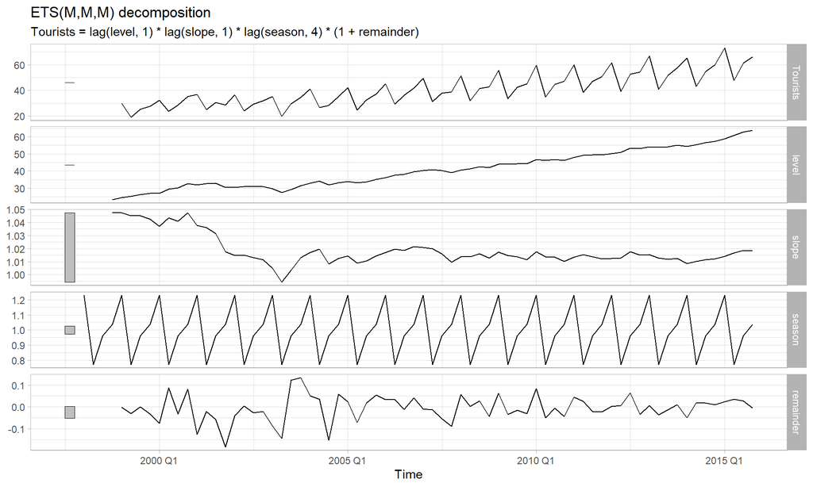

```r
components(tourist_MMM) |>  autoplot() + theme_light()
```

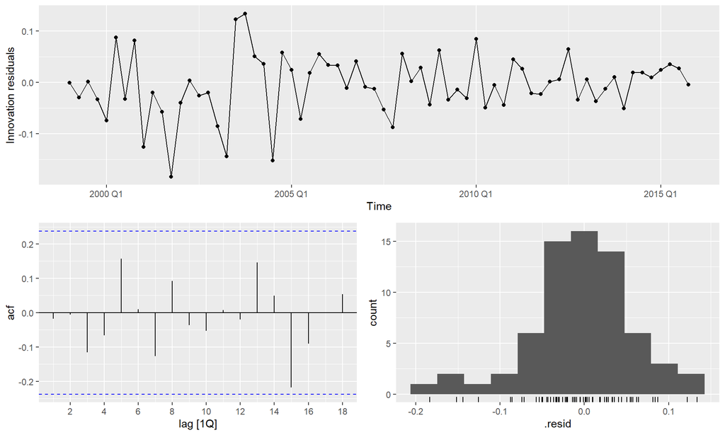

```r
# Extract residuals
residuals_tourists_MMM <- components(tourist_MMM)$remainder

# Residual plots
tourist_MMM |>  gg_tsresiduals()
```

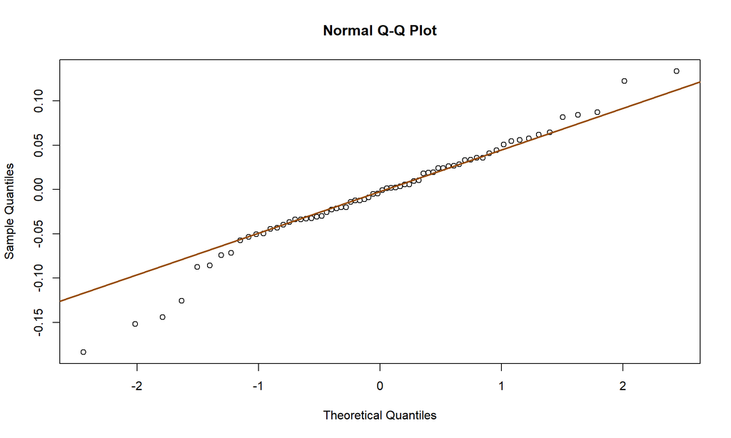

```r
# Normal qqplot of residuals
qqnorm(residuals_tourists_MMM)
qqline(residuals_tourists_MMM, col = "#964B00", lwd = 2)
```

```r
# Shapiro-Wilk test of normality
shapiro.test(residuals_tourists_MMM)
```

```
##
##  Shapiro-Wilk normality test
##
## data:  residuals_tourists_MMM
## W = 0.97209, p-value = 0.1305
```

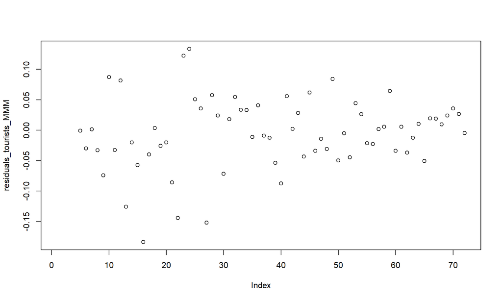

```r
# Scatterplot of residuals
plot(residuals_tourists_MMM)
```

```r
rm(residuals_tourists_MMM)
```

In the ETS(M, M, M) model, all three components are multiplicative. It is inferred by other observations made throughout this report that the seasonality will follow more closely to this effect. Therefore, we will keep seasonality as $M$, but will change the combination between error and trend to see which model is the best fit for this data. Before diving in, we run two models with an additional parameter, damped effect which is represented by $\phi$. If $\phi$ is between 0 and 1, this means that $\phi$ dampens the trend so that it approaches a constant some time in the future since a indefinite increasing or decreasing trend is not realistic.

## 4.7 ETS(M, Md, M): Holt-Winters

```r
tourist_MMdM <-  tourist |>
  model(
    `HW_MMdM` = ETS(Tourists ~ error("M") + trend("Md") + season("M")))

report(tourist_MMdM)
```

```
## Series: Tourists
## Model: ETS(M,Md,M)
##   Smoothing parameters:
##     alpha = 0.5235261
##     beta  = 0.0001000211
##     gamma = 0.0001000137
##     phi   = 0.9710257
##
##   Initial states:
##      l[0]     b[0]    s[0]    s[-1]    s[-2]    s[-3]
##  23.28837 1.034153 1.03476 0.959949 0.771347 1.233944
##
##   sigma^2:  0.0036
##
##      AIC     AICc      BIC
## 413.7327 417.5923 435.9277
```

```r
fabletools::accuracy(tourist_MMdM)
```

```
## # A tibble: 1 × 10
##   .model  .type       ME  RMSE   MAE    MPE  MAPE  MASE RMSSE     ACF1
##   <chr>   <chr>    <dbl> <dbl> <dbl>  <dbl> <dbl> <dbl> <dbl>    <dbl>
## 1 HW_MMdM Training 0.165  2.08  1.59 -0.178  4.21 0.529 0.587 -0.00443
```

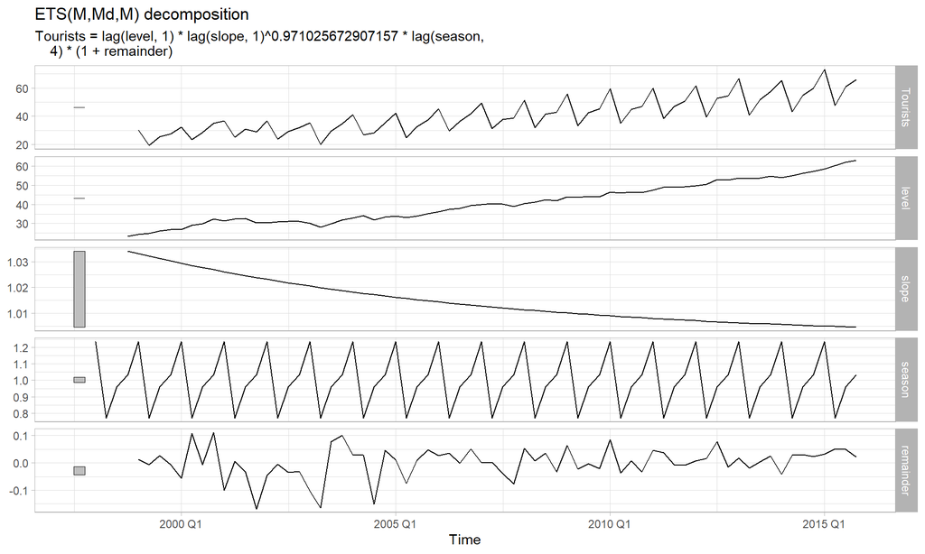

```r
components(tourist_MMdM) |>  autoplot() + theme_light()
```

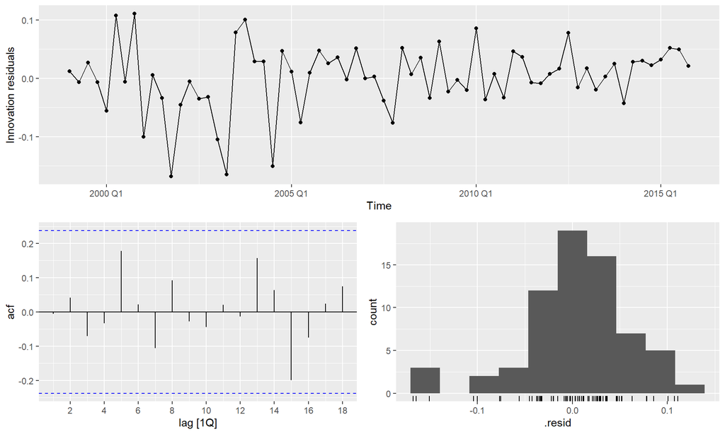

```r
# Extract residuals
residuals_tourist_MMdM <- components(tourist_MMdM)$remainder

# Residual plots
tourist_MMdM |>  gg_tsresiduals()
```

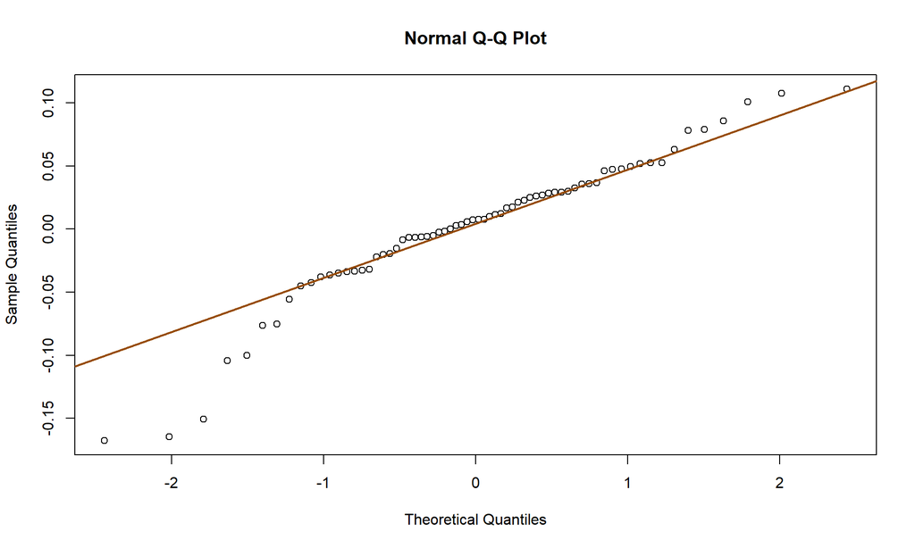

```r
# Normal qqplot of residuals
qqnorm(residuals_tourist_MMdM)
qqline(residuals_tourist_MMdM, col = "#964B00", lwd = 2)
```

```r
# Shapiro-Wilk test of normality
shapiro.test(residuals_tourist_MMdM)
```

```
##
##  Shapiro-Wilk normality test
##
## data:  residuals_tourist_MMdM
## W = 0.93903, p-value = 0.0024
```

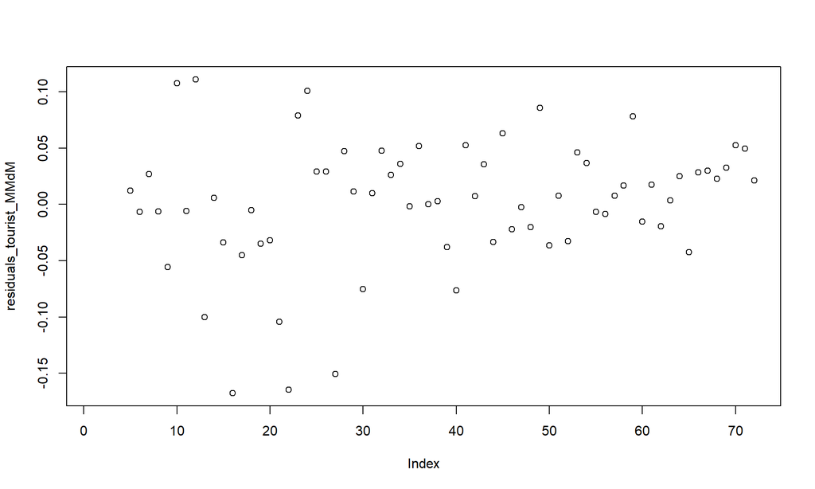

```r
# Scatterplot of residuals
plot(residuals_tourist_MMdM)
```

```r
rm(residuals_tourist_MMdM)
```

## 4.8 ETS(M, Ad, M): Holt-Winters

```r
tourist_MAdM <-  tourist |>
  model(
    `HW_MAdM` = ETS(Tourists ~ error("M") + trend("Ad") + season("M")))

report(tourist_MAdM)
```

```
## Series: Tourists
## Model: ETS(M,Ad,M)
##   Smoothing parameters:
##     alpha = 0.4839758
##     beta  = 0.003517281
##     gamma = 0.0001130978
##     phi   = 0.98
##
##   Initial states:
##      l[0]      b[0]     s[0]     s[-1]     s[-2]    s[-3]
##  23.54624 0.7983291 1.035306 0.9605063 0.7700786 1.234109
##
##   sigma^2:  0.0036
##
##      AIC     AICc      BIC
## 412.7260 416.5856 434.9210
```

```r
fabletools::accuracy(tourist_MAdM)
```

```
## # A tibble: 1 × 10
##   .model  .type       ME  RMSE   MAE   MPE  MAPE  MASE RMSSE   ACF1
##   <chr>   <chr>    <dbl> <dbl> <dbl> <dbl> <dbl> <dbl> <dbl>  <dbl>
## 1 HW_MAdM Training 0.314  2.08  1.61 0.198  4.20 0.533 0.586 0.0237
```

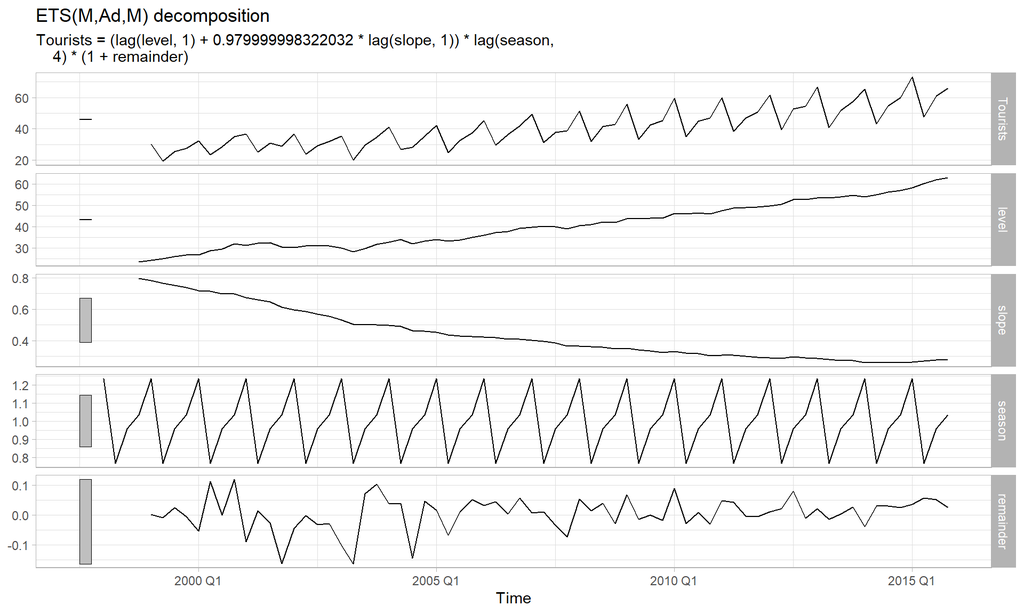

```r
components(tourist_MAdM) |>  autoplot() + theme_light()
```

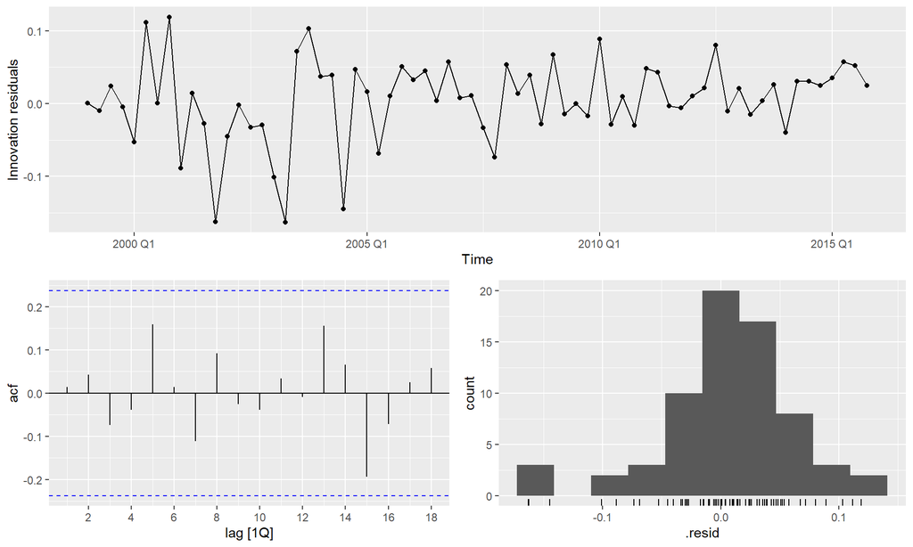

```r
# Extract residuals
residuals_tourist_MAdM <- components(tourist_MAdM)$remainder

# Residual plots
tourist_MAdM |>  gg_tsresiduals()
```

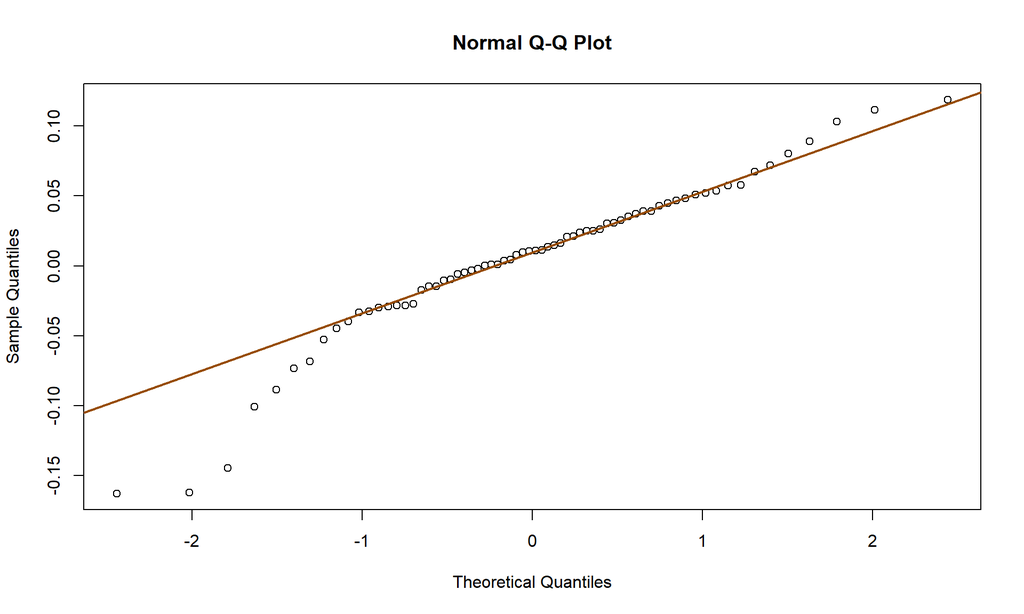

```r
# Normal qqplot of residuals
qqnorm(residuals_tourist_MAdM)
qqline(residuals_tourist_MAdM, col = "#964B00", lwd = 2)
```

```r
# Shapiro-Wilk test of normality
shapiro.test(residuals_tourist_MAdM)
```

```
##
##  Shapiro-Wilk normality test
##
## data:  residuals_tourist_MAdM
## W = 0.94205, p-value = 0.003367
```

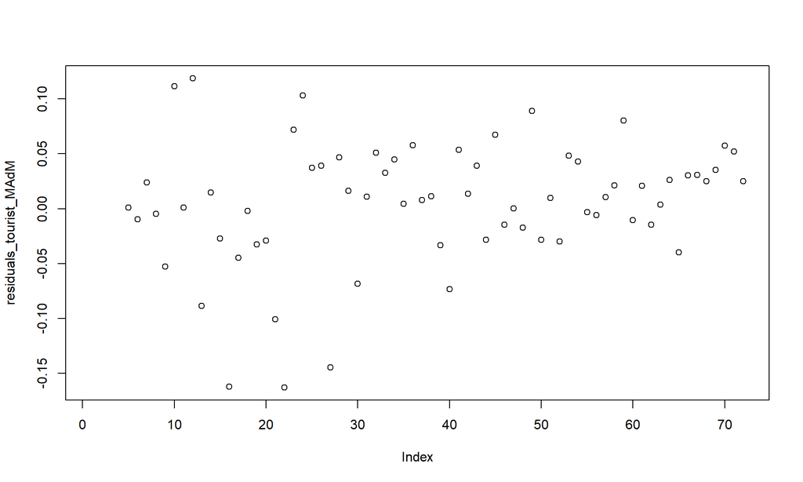

```r
# Scatterplot of residuals
plot(residuals_tourist_MAdM)
```

```r
rm(residuals_tourist_MAdM)
```

The models have a damped effect on the trends. According to the book, it is often seen that a Holt-Winters model with a damped trend and multiplicative seasonality provide the most accurate and robust forecasts. Even though this is mentioned, it is important to compare these results with an additional three other models that consider additive and multiplicative errors and trends in certain combinations.

## 4.9 ETS(A, A, M): Holt-Winters

```r
tourist_AAM <-  tourist |>
  model(
    `HW_AAM` = ETS(Tourists ~ error("A") + trend("A") + season("M")))

report(tourist_AAM)
```

```
## Series: Tourists
## Model: ETS(A,A,M)
##   Smoothing parameters:
##     alpha = 0.2680013
##     beta  = 0.00010424
##     gamma = 0.02473748
##
##   Initial states:
##      l[0]      b[0]     s[0]     s[-1]     s[-2]    s[-3]
##  24.42752 0.5767008 1.023506 0.9606971 0.7747944 1.241003
##
##   sigma^2:  4.6352
##
##      AIC     AICc      BIC
## 400.7051 403.8085 420.6806
```

```r
fabletools::accuracy(tourist_AAM)
```

```
## # A tibble: 1 × 10
##   .model .type         ME  RMSE   MAE    MPE  MAPE  MASE RMSSE  ACF1
##   <chr>  <chr>      <dbl> <dbl> <dbl>  <dbl> <dbl> <dbl> <dbl> <dbl>
## 1 HW_AAM Training -0.0553  2.02  1.51 -0.742  4.12 0.500 0.570 0.186
```

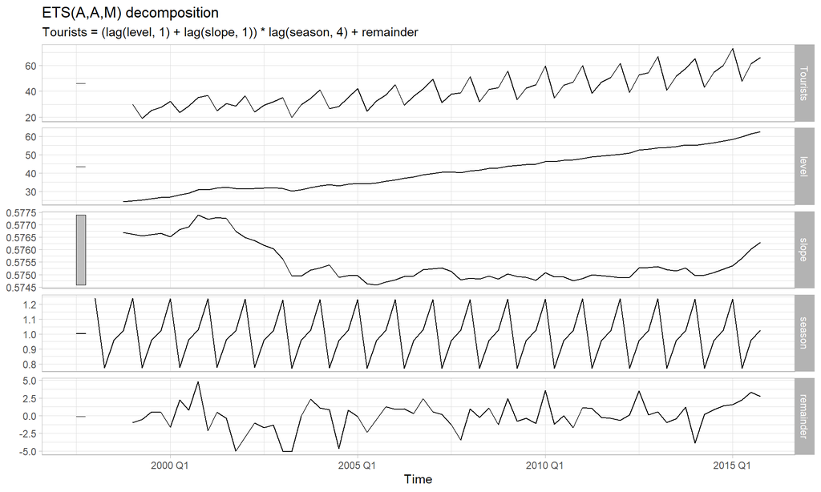

```r
components(tourist_AAM) |>  autoplot() + theme_light()
```

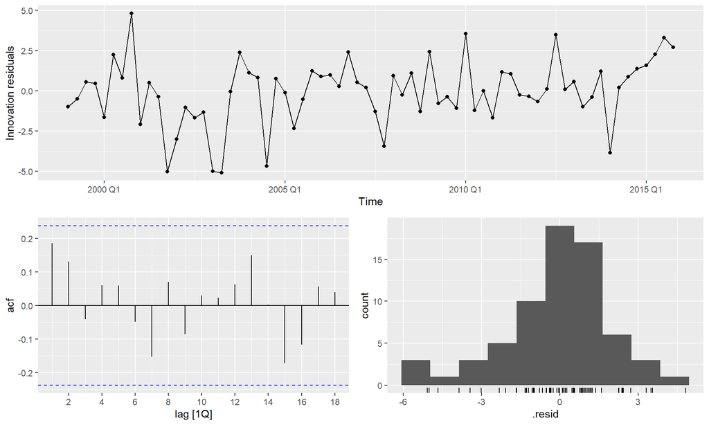

```r
# Extract residuals
residuals_tourist_AAM <- components(tourist_AAM)$remainder

# Residual plots
tourist_AAM |>  gg_tsresiduals()
```

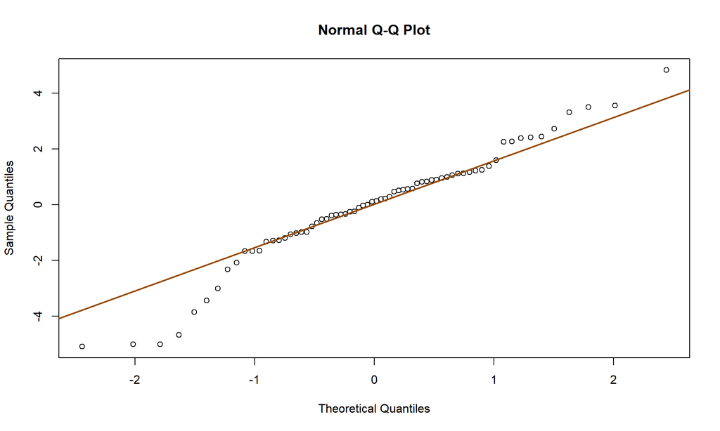

```r
# Normal qqplot of residuals
qqnorm(residuals_tourist_AAM)
qqline(residuals_tourist_AAM, col = "#964B00", lwd = 2)
```

```r
# Shapiro-Wilk test of normality
shapiro.test(residuals_tourist_AAM)
```

```
##
##  Shapiro-Wilk normality test
##
## data:  residuals_tourist_AAM
## W = 0.96222, p-value = 0.03746
```

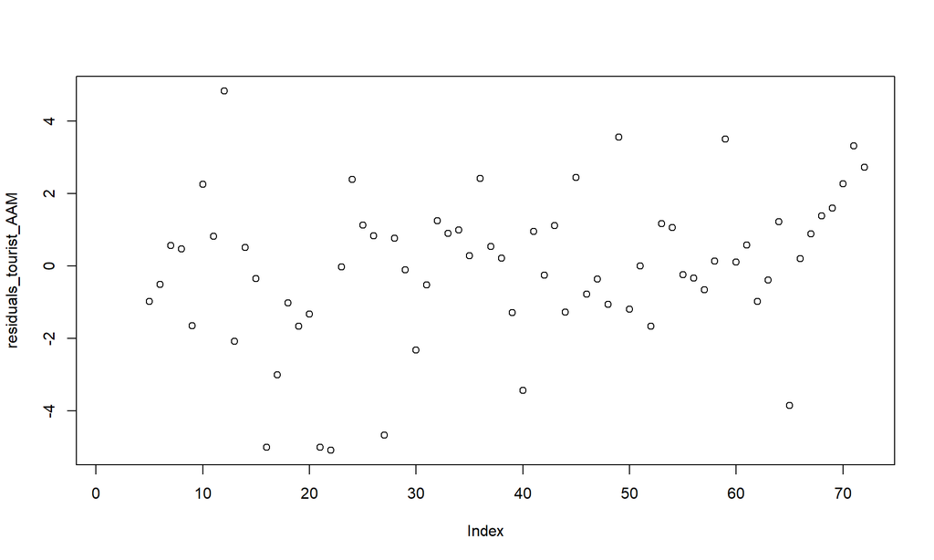

```r
# Scatterplot of residuals
plot(residuals_tourist_AAM)
```

```r
rm(residuals_tourist_AAM)
```

## 4.10 ETS(M, A, M): Holt-Winters

```r
tourist_MAM <-  tourist |>
  model(
    `HW_MAM` = ETS(Tourists ~ error("M") + trend("A") + season("M")))

report(tourist_MAM)
```

```
## Series: Tourists
## Model: ETS(M,A,M)
##   Smoothing parameters:
##     alpha = 0.3156214
##     beta  = 0.000100012
##     gamma = 0.0001000513
##
##   Initial states:
##      l[0]      b[0]     s[0]     s[-1]     s[-2]    s[-3]
##  24.74994 0.5124256 1.037134 0.9596034 0.7701713 1.233091
##
##   sigma^2:  0.0035
##
##      AIC     AICc      BIC
## 409.5036 412.6070 429.4792
```

```r
fabletools::accuracy(tourist_MAM)
```

```
## # A tibble: 1 × 10
##   .model .type       ME  RMSE   MAE    MPE  MAPE  MASE RMSSE  ACF1
##   <chr>  <chr>    <dbl> <dbl> <dbl>  <dbl> <dbl> <dbl> <dbl> <dbl>
## 1 HW_MAM Training 0.135  1.99  1.53 -0.217  4.12 0.509 0.562 0.131
```

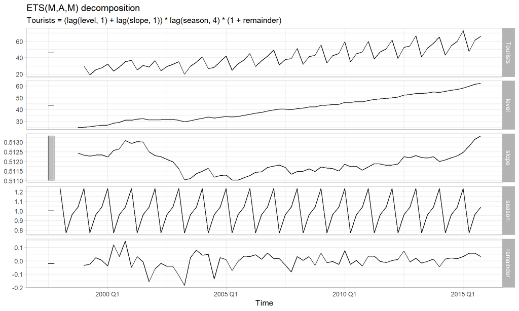

```r
components(tourist_MAM) |>  autoplot() + theme_light()
```

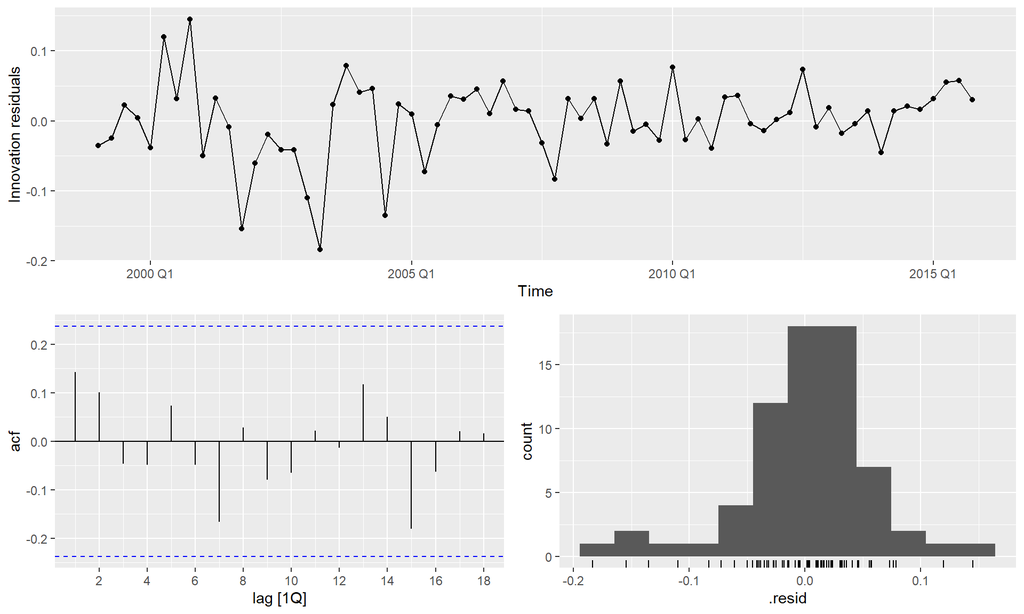

```r
# Extract residuals
residuals_tourist_MAM <- components(tourist_MAM)$remainder

# Residual plots
tourist_MAM |>  gg_tsresiduals()
```

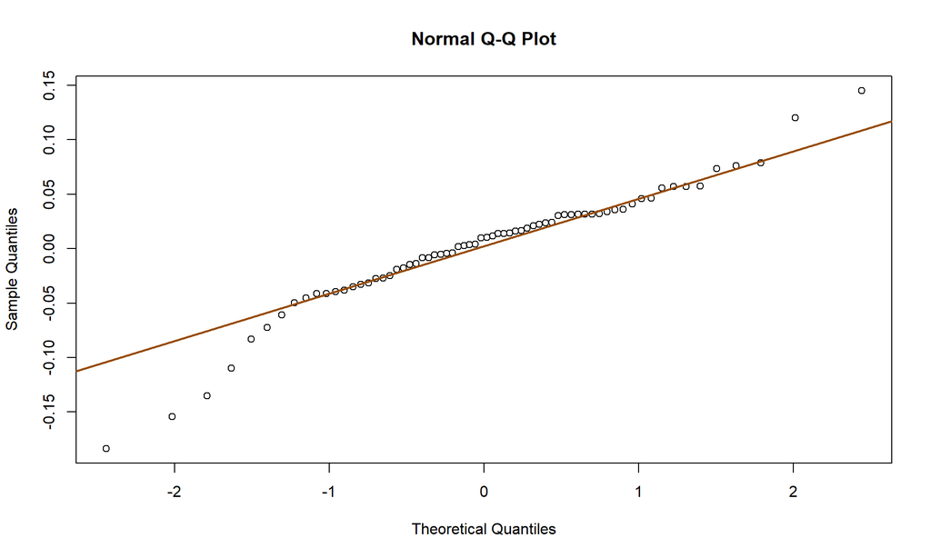

```r
# Normal qqplot of residuals
qqnorm(residuals_tourist_MAM)
qqline(residuals_tourist_MAM, col = "#964B00", lwd = 2)
```

```r
# Shapiro-Wilk test of normality
shapiro.test(residuals_tourist_MAM)
```

```
##
##  Shapiro-Wilk normality test
##
## data:  residuals_tourist_MAM
## W = 0.9429, p-value = 0.003704
```

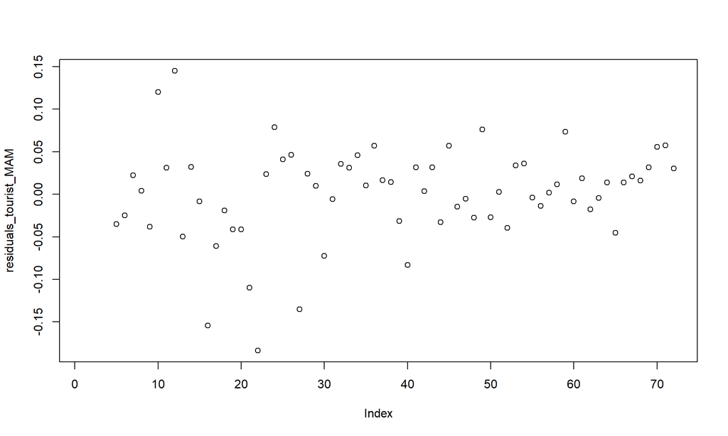

```r
# Scatterplot of residuals
plot(residuals_tourist_MAM)
```

```r
rm(residuals_tourist_MAM)
```

## 4.11 ETS(A, M, M): Holt-Winters

```r
tourist_AMM <-  tourist |>
  model(
    `HW_AMM` = ETS(Tourists ~ error("A") + trend("M") + season("M")))

report(tourist_AMM)
```

```
## Series: Tourists
## Model: ETS(A,M,M)
##   Smoothing parameters:
##     alpha = 0.225769
##     beta  = 0.0001000006
##     gamma = 0.08461337
##
##   Initial states:
##      l[0]     b[0]     s[0]     s[-1]     s[-2]   s[-3]
##  23.81626 1.013876 1.030574 0.9725688 0.7537471 1.24311
##
##   sigma^2:  4.6266
##
##      AIC     AICc      BIC
## 400.5796 403.6830 420.5551
```

```r
fabletools::accuracy(tourist_AMM)
```

```
## # A tibble: 1 × 10
##   .model .type        ME  RMSE   MAE    MPE  MAPE  MASE RMSSE  ACF1
##   <chr>  <chr>     <dbl> <dbl> <dbl>  <dbl> <dbl> <dbl> <dbl> <dbl>
## 1 HW_AMM Training 0.0245  2.02  1.52 -0.116  4.20 0.503 0.570 0.168
```

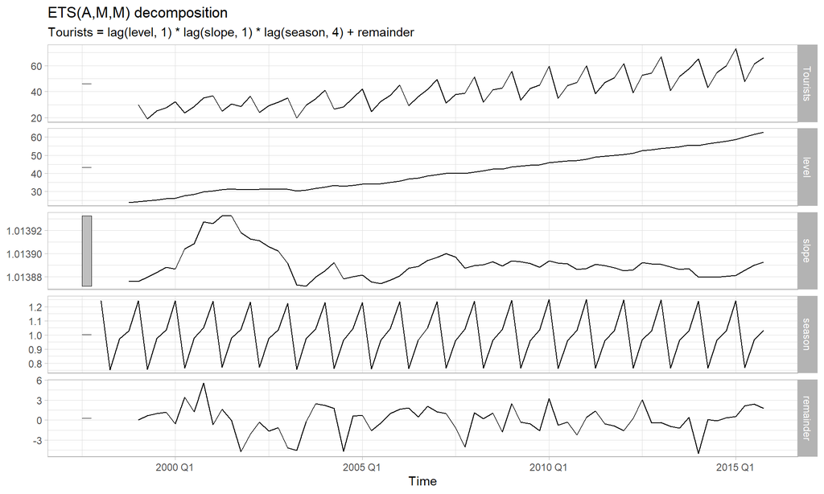

```r
components(tourist_AMM) |>  autoplot() + theme_light()
```

After running more models with these error and trend combinations, the best model proved to be the Holt-Winters (A, M, M). There are several comments about this method:

• The trend appears to be increasing in the beginning of the series, but decreases after several years. Then, it maintains a more or less constant slope. In 2015 though, there is that slight uptick again. This is one of the main reasons this multiplicative trend was selected.

• The model has been identified as having a quarterly season pattern.

• The remainder does not show any patterns.

The smoothing parameters can be described as:

• $\alpha$: At 0.23, there is more weight given to observations from the more distant past.

• $\beta$: A very small value indicates that the trend does not change often.

• $\gamma$: The parameter has a small number, meaning that the older values in X direction are weighted more heavily.

Below shows the component form for the the multiplicative method. For our model though, a certain component will need to be changed later.

• Forecast equation: $\hat{y}_{t+h|t} = (l_t+ hb_t)s_{t+h-m(k+1)}$  
• Level equation: $l_t = {\alpha}\frac{y_t}{s_{t-m}} + (1 - \alpha)(l_{t-1} + b_{t-1})$  
• Trend equation: $b_t = {\beta}^*({l_t} - l_{t-1}) + (1 - {\beta}^*)b_{t-1}$  
• Seasonal equation: $s_t = {\gamma}\frac{y_t}{(t_{t-1} + b_{t-1})} + (1 - \gamma)s_{t-m}$

For this final model, we will review the residuals.

### 4.11.1 Final Model Residual Check

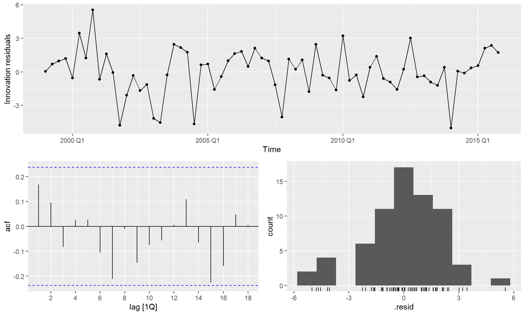

```r
# Extract residuals
residuals_tourists <- components(tourist_AMM)$remainder

# Residual plots
tourist_AMM |>  gg_tsresiduals()
```

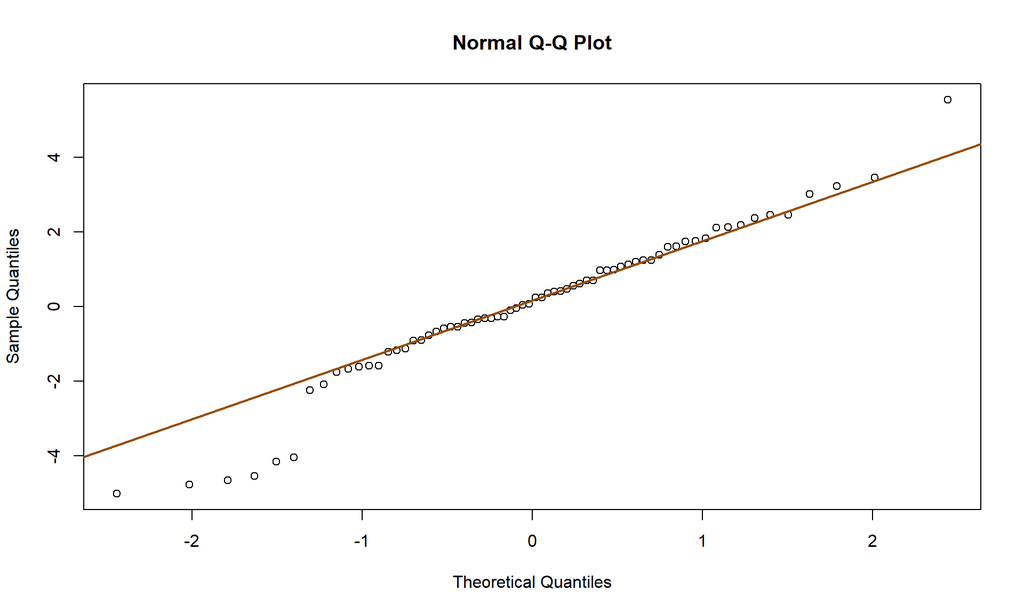

```r
# Normal qqplot of residuals
qqnorm(residuals_tourists)
qqline(residuals_tourists, col = "#964B00", lwd = 2)
```

```r
# Shapiro-Wilk test of normality
shapiro.test(residuals_tourists)
```

```
##
##  Shapiro-Wilk normality test
##
## data:  residuals_tourists
## W = 0.95962, p-value = 0.02706
```

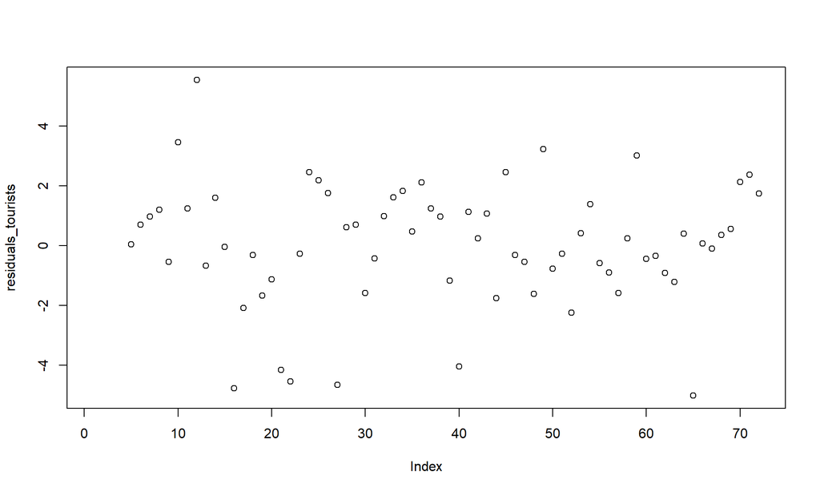

```r
# Scatterplot of residuals
plot(residuals_tourists)
```

Although checking residuals is not essential for forecasting, it makes calculating the prediction intervals much easier. Therefore, they should be checked to see if they are follow the necessary assumptions. By using the gg_tsresiduals() function, it is seen that the errors look skewed. The correlogram does not show any lags that exceed the dashed blue lines which indicate whether the correlations are significantly different from zero. In addition, the residual plot shows the random scatter of points around zero, revealing constant variance and homoscedasticity.

The QQ Plot of residuals appears to be non-normal due to the points by the tails being far away from the line that represents the expected values. To determine if the residuals are normally distributed, we run a statistical test, Shapiro-Wilk. The null hypothesis is that the errors are normally distributed. Since the p-value is less than $\alpha$ at 0.05, there is enough evidence to reject the null hypothesis. The residuals can be assumed to not be normally distributed. Overall, forecasts from this method may be good, but the prediction intervals may be inaccurate since we do not have normality.

```r
augment(tourist_AMM)
```

```
## # A tsibble: 68 x 6 [1Q]
## # Key:       .model [1]
##    .model    Time Tourists .fitted  .resid  .innov
##    <chr>    <qtr>    <dbl>   <dbl>   <dbl>   <dbl>
##  1 HW_AMM 1999 Q1     30.1    30.0  0.0355  0.0355
##  2 HW_AMM 1999 Q2     19.1    18.5  0.691   0.691
##  3 HW_AMM 1999 Q3     25.3    24.4  0.967   0.967
##  4 HW_AMM 1999 Q4     27.6    26.4  1.20    1.20
##  5 HW_AMM 2000 Q1     32.1    32.6 -0.539  -0.539
##  6 HW_AMM 2000 Q2     23.5    20.0  3.45    3.45
##  7 HW_AMM 2000 Q3     28.5    27.2  1.24    1.24
##  8 HW_AMM 2000 Q4     35.1    29.6  5.55    5.55
##  9 HW_AMM 2001 Q1     36.8    37.5 -0.675  -0.675
## 10 HW_AMM 2001 Q2     25.0    23.4  1.60    1.60
## # … with 58 more rows
```

The table shows the fitted values and residuals of the ETS(A, M, M) model for all periods. The other three columns note the following:

• .fitted contains the fitted values

• .resid contains the residuals

• .innov contains the “innovation residuals” which, in this case, are identical to the regular residuals

## 4.12 Forecast Error Comparison

According to Chapter 3.4, forecast “error” is the difference between an observed value and its forecast. “Error” does not mean a mistake, but the unpredictable part of an observation. It can be written as: $e_{T+h} = y_{T+h} - \hat{y}_{T+h|T}$.

In this section, we will compare all models relative to their AIC, AICc, BIC, RMSE, and Sharpio-Wilk values to ensure that the final model was the best fit and how the forecast errors look against each other.

```r
# Create a data frame with three columns: Name, Age, and Gender
my_table <- data.frame(
  Model = c("A, N, N", "M, N, N", "A, A, N", "M, M, N", "M, M, M", "M, Md, M", "M, Ad, M", "A, A, M", "M, A, M", "A, M, M"),
  AIC = c(581.02, 573.38, 567.81, 564.54, 418.43, 413.73, 412.73, 400.71, 409.50, 400.58),
  AICc = c(581.40, 573.75, 568.78, 565.50, 421.53, 417.59, 416.59, 403.81, 412.61, 403.68),
  BIC = c(587.68, 580.04, 578.90, 575.63, 438.40, 435.93, 434.92, 420.68, 429.48, 420.56),
  RMSE = c(8.32, 8.32, 7.32, 7.48, 2.16, 2.08, 2.08, 2.02, 1.99, 2.02),
  Shapiro_Wilk = c(0.06, 0.02, 0.14, 0.07, 0.13, 0.00, 0.00, 0.04, 0.00, 0.03))

# Print the table
print(my_table)
```

```
##       Model    AIC   AICc    BIC RMSE Shapiro_Wilk
## 1   A, N, N 581.02 581.40 587.68 8.32         0.06
## 2   M, N, N 573.38 573.75 580.04 8.32         0.02
## 3   A, A, N 567.81 568.78 578.90 7.32         0.14
## 4   M, M, N 564.54 565.50 575.63 7.48         0.07
## 5   M, M, M 418.43 421.53 438.40 2.16         0.13
## 6  M, Md, M 413.73 417.59 435.93 2.08         0.00
## 7  M, Ad, M 412.73 416.59 434.92 2.08         0.00
## 8   A, A, M 400.71 403.81 420.68 2.02         0.04
## 9   M, A, M 409.50 412.61 429.48 1.99         0.00
## 10  A, M, M 400.58 403.68 420.56 2.02         0.03
```

# 5 Question D

Compute a h = 10 forecast and prediction intervals for different levels: 80%, 90%, 95% and 99%.

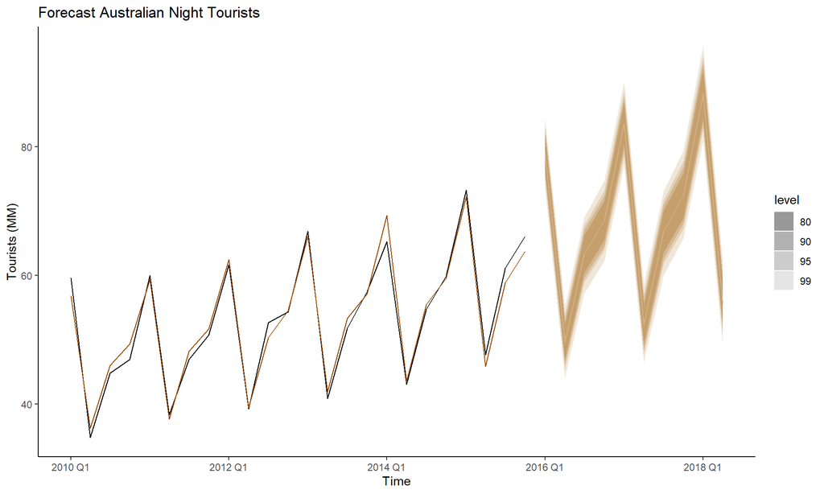

```r
tourist_AMM_fc <- tourist_AMM |> forecast(h = 10)

tourist_forecast <- tourist[c(45:68),]

tourist_AMMF <-  tourist_forecast |>
  model(
    `HW_AMMF` = ETS(Tourists ~ error("A") + trend("M") + season("M")))

CI = c(80, 90, 95, 99) # Confidence intervals

# Plot data and forecast
tourist_AMM_fc |>
  autoplot(tourist_forecast, color = "#D2B48C", level = CI) +
  geom_line(aes(y = .fitted), col="#964B00",
            data = augment(tourist_AMMF)) +
  labs(title = "Forecast Australian Night Tourists", x = "Time", y = "Tourists (MM)") + theme_classic()
```

When obtaining a forecast, the analyst is estimating the middle of the range of possible values for the random variable. This average is typically called point forecasts for future values, which then are accompanied by prediction intervals.

```r
# ETS model
PT <- hilo(tourist_AMM_fc, level = CI) # layered %
PT |>  select(c(5:8))
```

```
## # A tsibble: 10 x 5 [1Q]
##                     `80%`                  `90%`                  `95%`
##                    <hilo>                 <hilo>                 <hilo>
##  1 [76.31096, 81.79878]80 [75.39808, 82.53560]90 [74.63411, 83.13215]95
##  2 [46.88769, 52.33065]80 [46.18221, 53.12523]90 [45.43106, 53.83513]95
##  3 [60.42292, 66.20606]80 [59.60026, 67.03212]90 [58.95154, 67.73027]95
##  4 [65.49809, 71.51648]80 [64.53654, 72.34346]90 [63.89616, 73.17097]95
##  5 [80.35386, 86.84526]80 [79.35257, 87.79806]90 [78.54458, 88.64863]95
##  6 [49.32830, 55.42361]80 [48.45824, 56.37479]90 [47.78310, 57.14790]95
##  7 [63.57240, 70.06059]80 [62.62353, 70.93358]90 [61.84308, 71.65331]95
##  8 [68.89039, 75.75412]80 [68.03136, 76.78335]90 [67.21670, 77.71942]95
##  9 [84.46845, 92.00758]80 [83.41983, 93.08511]90 [82.69883, 94.00314]95
## 10 [52.14949, 58.73858]80 [51.20697, 59.69207]90 [50.47111, 60.42145]95
## # … with 2 more variables: `99%` <hilo>, Time <qtr>
```

According to Chapter 5.5, a prediction interval gives an interval within which we expect $y_t$ to lie within a specified probability. Although the distribution is non-normal, we can still calculate the future observations through $\hat{y}_{T+h|T} \pm c\hat{\sigma}_h$. The faint white line (point forecast) in the middle of the shaded areas is the forecast for the next 2.5 years, which captured the historical seasonal pattern. Those ten periods are based on the Holt_Winters (A,M,M) model since this proved to be the best method. This forecast uses various levels, such as 80, 90, 95, and 99. Relating to all of those percentages, each have a multiplier, $c$, that have different values. For example, the multiplier for 95% is 1.96 and 99% is 2.58. All of the levels appear very close in prediction for that specific period, and this will be reviewed in the next table. For simplicity, the forecast starts at 2010 Q1, which is represented by the brown line. This hugs the original data pretty close. There are some points where the forecast overestimates what actually happened, like in 2014 Q1. Another example where the forecast over predicts is in specific quarters from Q2 to Q3. On the other hand, there are a couple underestimates like towards the end of the provided data in 2015. Overall, the prediction intervals display the uncertainty in forecasts. Since these are expected to be accurate, those intervals will be more narrow.

Within the table above, it shows the prediction intervals within the four levels. As stated earlier, they all appear to have similar values between the minimum and maximum value as it is built off of the best model determined.

# 6 Question E

Compute a h = 10 forecast and prediction intervals for the same levels of the previous point, this time by using bootstrapping: a) assuming normality of residuals and b) sampling based on your fitted model’s residuals.

• Forecast equation: $y_t= l_{t-1}b_{t-1}s_{t-m}+ \epsilon_t$  
• Level equation: $l_t = l_{t-1}b_{t-1} + \frac{{\alpha}{\epsilon_t}}{s_{t-m}}$  
• Trend equation: $b_t = b_{t-1} + \frac{{\beta}{\epsilon_t}}{({s_{t-m}}l_{t-1})}$  
• Seasonal equation: $s_t = s_{t-m} + \frac{{\gamma}{\epsilon_t}}{(l_{t-1}b_{t-1})}$

In Section 1.7, it outlines that what we are trying to forecast is unknown and can think of it as a random variable. Therefore, we can utilize the method of bootstrapping. It is used for a time series in order to simulate future values of a series using a model by the residuals. Sometimes, this is used because the normal distribution does not fit to the errors. From the residual analysis earlier for the final model, it had a non-normal distribution. The idea is to draw at random the new error from the sample of estimated errors with replacement. Instead of simulating with normality, we simulate a random sample of independent errors from the set with equal probability. Since there are many samples, this gives Australia an insight of how many international tourists they should expect in the next ten quarters. By applying this method, it can help the country quantify uncertainty in the near future to combat any potential challenges from the historical data that was previously collected. Additionally, bootstrapping would allow the analyst to know the prediction intervals which are based on a normal distribution. There were four prediction intervals that are included: 80, 90, 95, and 99.

```r
L72 <- components(tourist_AMM)$level[72]

B72 <- components(tourist_AMM)$slope[72]

S69 <- components(tourist_AMM)$season[69]
S70 <- components(tourist_AMM)$season[70]
S71 <- components(tourist_AMM)$season[71]
S72 <- components(tourist_AMM)$season[72]

sigma <- as.numeric(sqrt( tourist_AMM[[1]][[1]]$fit$fit["sigma2"] ))

alpha <- tourist_AMM[[1]][[1]]$fit$par$estimate[1]

beta <- tourist_AMM[[1]][[1]]$fit$par$estimate[2]

gamma <- tourist_AMM[[1]][[1]]$fit$par$estimate[3]

residuals = components(tourist_AMM)$remainder[5:72]

A <- components(tourist_AMM)$season
dim(A) <- c(4, 18)
A <- t(A)
```

```r
knitr::kable(matrix(c("alpha", "beta", "phi", "L72", "B72", "S69","S70","S71","S72", alpha, beta, gamma, L72, B72, S69, S70, S71, S72), nrow = 9), col.names = c("Parameter", "Value"))
```

[output not shown]

These nine values were extracted for the state space model. Since this model has seasonlity, the calculation for that component is not exact, but close to the best representation of how it should be modeled by accoutning for each of the seasons individually.

[figure not shown]

```r
h.step <- 10      # number of steps ahead for forecast
R <- 100    # number of repetitions

# creating empty matrices that will be filled as we make computations
l.mat <- matrix(nrow = h.step, ncol = R)
b.mat <- matrix(nrow = h.step, ncol = R)
y <- matrix(nrow = h.step, ncol = R)

# initialization of y_31, b_31 and l_31 for h = 1
# set the random seed to have always the same random numbers generation
set.seed(1)
eps <- sample(residuals, size = R, replace = TRUE)

y[1,]  <- L72*B72*S69 + eps
l.mat[1,] <- L72*B72 + alpha*eps/S69
b.mat[1,] <- B72 + beta*eps/(S69*L72)

# the loop for the next steps, h = 2 to h = h.step (10 here)

for (h in 2:h.step) {

  set.seed(h)
  eps <- sample(residuals, size = R, replace = TRUE)

  forecast_row = 72 + h
  # 69 mod 4 = 1
  # 70 mod 4 = 2
  # 71 mod 4 = 3
  # 72 mod 4 = 0

  if (forecast_row %% 4 == 1) {
    season_coeff = S69
  } else if (forecast_row %% 4 == 2) {
    season_coeff = S70
  } else if (forecast_row %% 4 == 3) {
    season_coeff = S71
  } else if (forecast_row %% 4 == 0) {
    season_coeff = S72
  }

  y[h,]     <- l.mat[h-1,]*b.mat[h-1,]*season_coeff + eps
  l.mat[h,] <- l.mat[h-1,]*b.mat[h-1,] + alpha*eps/season_coeff
  b.mat[h,] <- b.mat[h-1,] + beta*eps/(season_coeff*l.mat[h-1,])
}

plot(x = 1:68, y = tourist$Tourists,
     xlim=c(0, 80), ylim=c(0, 90),
     type='l', lwd=1,
     main = "Bootstrap 1,000 Errors " , xlab = "Quarter", ylab = "Australian Night Tourists (MM)")

# Loop for the repetition of the forecast
for(j in c(1:R)) {
  points(x = 69:78, y = y[,j], type = "l", lwd = 1, col="#964B00")
}
```

```r
CI = apply(y, 1, quantile, probs = c(0.80, 0.90, 0.95, 0.99))
CI = t(CI)
CI
```

```
##            80%      90%      95%      99%
##  [1,] 80.27221 81.11287 81.45334 82.22847
##  [2,] 51.75130 52.67021 53.31961 55.15823
##  [3,] 64.89644 65.70838 66.16600 69.11581
##  [4,] 69.81829 70.91555 71.56880 73.78328
##  [5,] 85.48757 86.53425 87.03141 89.58817
##  [6,] 54.29795 55.23090 56.15147 58.67653
##  [7,] 69.19084 70.13479 71.88665 72.80885
##  [8,] 74.46174 76.03555 76.93665 79.94413
##  [9,] 90.10792 91.14569 92.83452 94.25416
## [10,] 57.31942 58.28062 59.23192 61.09473
```

Since our residuals are non-normal, we now assume normality of residuals to see their distribution and prediction intervals.

[figure not shown]

```r
h.step <- 10      # number of steps ahead for forecast
R <- 100    # number of repetitions

# creating empty matrices that will be filled as we make computations
l.mat <- matrix(nrow = h.step, ncol = R)
b.mat <- matrix(nrow = h.step, ncol = R)
y <- matrix(nrow = h.step, ncol = R)

# initialization of y_31, b_31 and l_31 for h = 1
# set the random seed to have always the same random numbers generation
set.seed(1)
eps <- rnorm(n = R, mean = 0 , sd = sigma)

y[1,]  <- L72*B72*S69 + eps
l.mat[1,] <- L72*B72 + alpha*eps/S69
b.mat[1,] <- B72 + beta*eps/(S69*L72)

# the loop for the next steps, h = 2 to h = h.step (10 here)

for (h in 2:h.step) {

  set.seed(h)
  eps <- rnorm(n = R, mean = 0 , sd = sigma)

  forecast_row = 72 + h
  # 69 mod 4 = 1
  # 70 mod 4 = 2
  # 71 mod 4 = 3
  # 72 mod 4 = 0

  if (forecast_row %% 4 == 1) {
    season_coeff = S69
  } else if (forecast_row %% 4 == 2) {
    season_coeff = S70
  } else if (forecast_row %% 4 == 3) {
    season_coeff = S71
  } else if (forecast_row %% 4 == 0) {
    season_coeff = S72
  }

  y[h,]     <- l.mat[h-1,]*b.mat[h-1,]*season_coeff + eps
  l.mat[h,] <- l.mat[h-1,]*b.mat[h-1,] + alpha*eps/season_coeff
  b.mat[h,] <- b.mat[h-1,] + beta*eps/(season_coeff*l.mat[h-1,])
}

plot(x = 1:68, y = tourist$Tourists,
     xlim=c(0, 80), ylim=c(0, 90),
     type='l', lwd=1,
     main = "Normalized Bootstrap 1,000 Errors " , xlab = "Quarter", ylab = "Australian Night Tourists (MM)")

# Loop for the repetition of the forecast
for(j in c(1:R)) {
  points(x = 69:78, y = y[,j], type = "l", lwd = 1, col="#964B00")
}
```

```r
CI = apply(y, 1, quantile, probs = c(0.80, 0.90, 0.95, 0.99))
CI = t(CI)
CI
```

```
##            80%      90%      95%      99%
##  [1,] 80.66538 81.54687 82.26630 83.68457
##  [2,] 51.91525 53.22635 53.78677 54.05355
##  [3,] 64.84691 65.78270 66.32889 66.80536
##  [4,] 70.91383 72.09486 72.66809 73.55828
##  [5,] 85.74385 87.26259 88.19402 88.63638
##  [6,] 54.68597 55.73294 57.14260 58.46001
##  [7,] 69.71345 70.69667 71.32332 72.20733
##  [8,] 74.72415 76.12529 77.18877 78.72962
##  [9,] 90.89751 91.97993 93.76872 94.71681
## [10,] 57.32598 58.19094 58.93300 60.03847
```

# 7 Resources

- https://openforecast.org/adam/ETSTaxonomyMaths.html\
- https://www.zoho.com/analytics/help/connectors/how-forecasting-works.html\
- Forecasting: Principles and Practice (3rd ed)
- Forecasting: Principles and Practice (2nd ed)